# Bringing It All Together

Data Analytics for Finance

Caspar David Peter

peter@rsm.nl

Rotterdam School of Management, Accounting Department

# Bringing It All Together

## Before We Start…

### Assignment Release and Submission Schedule

| Assignment | Release | Deadline | Graded |
| --- | --- | --- | --- |
| A1 | 11.02.2026 | 25.02.2026 | $\checkmark$ |
| A2 | 11.02.2026 | 25.02.2026 | $\checkmark$ |
| A3 | 18.02.2026 | 04.03.2026 | $\checkmark$ |
| A4 | 25.02.2026 | 11.03.2026 |  |
| A5 | 04.03.2026 | 18.03.2026 |  |
| A6 | **11.03.2026** | **25.03.2026** |  |

**Assignment 6!**

A6 is the **replication exercise**. You will replicate Huck (2024) using Dutch data. Everything we discuss today feeds directly into it. Deadline: **March 25, 2026**.

## Overview

### Today’s agenda

#### Part 1: Where We’ve Been

- Recap of Lectures 1–5
- The empirical researcher’s toolkit

#### Part 2: The Paper

- Huck (2024) in *RFS*
- Every section mapped to your toolkit

#### Part 3: Your Turn

- Assignment 6: Dutch replication
- Walkthrough

#### Part 4: Wrap-Up

- Thesis connection
- The role of AI in your workflow

## Overview

### Learning objectives

#### By the end of today, you will be able to

- Recognize how the course’s methods connect to published research
- Understand the research design and identification strategy of Huck (2024)
- Interpret and critically evaluate replication results in a new setting
- Write a discussion of findings, limitations, and extensions
- Connect this exercise to your MSc thesis

**Why this matters**

You are about to do exactly what thesis Module 2 asks: read a published paper, replicate the methodology with new data, and evaluate whether findings generalize.

# Part 1: Where We’ve Been

## Where We’ve Been

### The journey in one picture

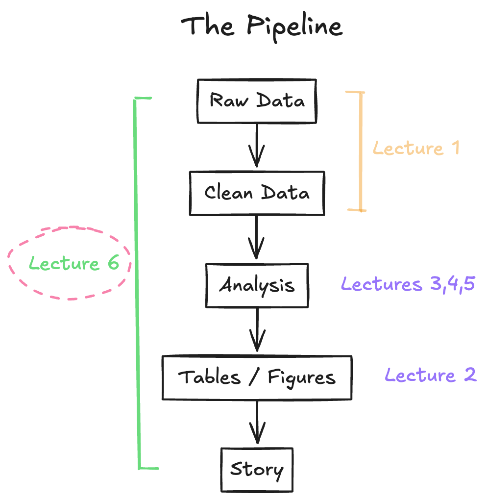

Each lecture added a layer to your empirical toolkit. Today we see how they work together in a single published paper and in your own replication.

## Lecture 1: From Messy Data to Research Insights

### The foundation: You can’t analyze what you can’t structure

#### Key takeaways

- Research starts with data wrangling, not regressions
- Raw data is messy: missing values, inconsistent formats, multiple sources
- The pipeline: import ⤏ clean ⤏ transform ⤏ merge ⤏ analyze
- Tools: Stata, `merge`, `reshape`, `collapse`, `gen`/`replace`

#### From this course

- Compustat Global via WRDS
- The “tidy data” principle: one row per observation unit
- Optional: SQL DB for efficient data management

**Remember this?**

In every assignment, you spent **60–70% of your time on data preparation**. That’s research. **Facts!**

## Lecture 2: Data Exploration & Visualization

### Look before you run regressions

#### Key takeaways

- Visualization is diagnosis, not decoration
- Summary statistics reveal distributions, outliers, patterns
- Histograms, scatter plots, time series — each serves a purpose
- Always check your data *before* running regressions

#### Application

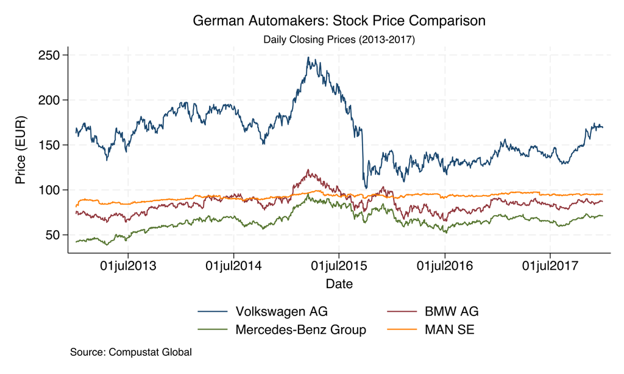

**The principle**

If your regression tells you something your visualization doesn’t support. Trust the visualization and debug the regression.

## Lecture 3: Regressions & Identification

### The sign-flip — OVB can reverse your conclusions

#### Key takeaways

- Identification = isolating causal variation
- Endogeneity: X correlated with the error term
  - Selection bias: who self-selects into treatment
  - Omitted variable bias: what you forgot to control for
- Experiments as the gold standard
- OLS: the workhorse, but only as good as your identification

#### The DiLLMa lesson

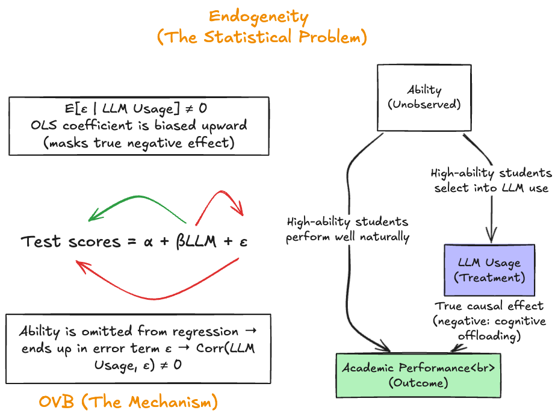

> OVB doesn’t just make estimates imprecise, it can flip the sign!

## Lecture 4: Panel Data Methods

### Control for what you can’t measure

#### Key takeaways

- Panel data: multiple units observed over time
- Fixed effects absorb unobserved heterogeneity
  - Entity FE: time-invariant characteristics
  - Time FE: common shocks across units
- Difference-in-Differences: treatment vs control, before vs after
- Parallel trends assumption as the key identification requirement

#### From this course

- Dieselgate as a natural experiment
- Within-firm variation: same VW before vs after scandal
- Staggered adoption and modern DiD advances (Sun & Abraham, Callaway & Sant’Anna)
- Clustering standard errors by the right dimension

**The intuition**

If you can’t run an experiment and can’t observe all confounders, panel methods let you difference them out.

## Lecture 4: Panel Data Methods

### Control for what you can’t measure

#### Key takeaways

- Panel data: multiple units observed over time
- Fixed effects absorb unobserved heterogeneity
  - Entity FE: time-invariant characteristics
  - Time FE: common shocks across units
- Difference-in-Differences: treatment vs control, before vs after
- Parallel trends assumption as the key identification requirement

#### Key picture

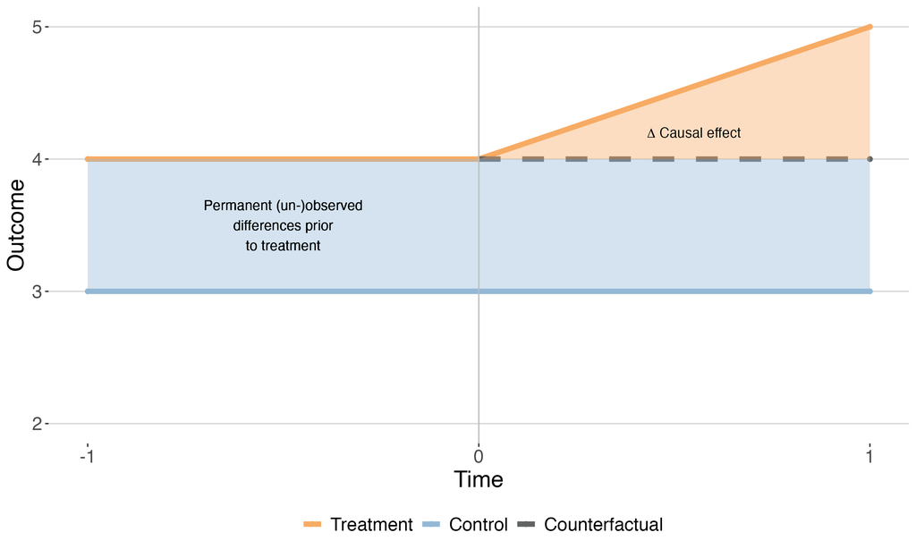

**The intuition**

If you can’t run an experiment and can’t observe all confounders, panel methods let you difference them out.

## Lecture 5: Event Studies & Fama–MacBeth

### Specialized tools for finance

#### Event Studies

- Short-window test of market reactions
- Estimation window ⤏ expected return model ⤏ abnormal returns ⤏ CARs
- The “counterfactual” is the factor model prediction
- Same logic as DiD, but at daily frequency
- Leads and lags reveal timing of information incorporation

#### Key picture

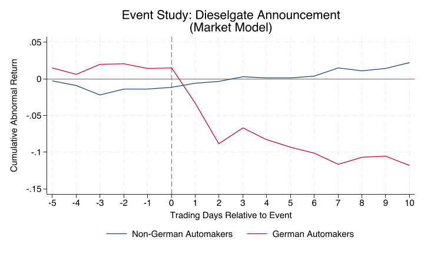

## Lecture 5: Event Studies & Fama–MacBeth

### Specialized tools for finance

#### Event Studies

- Short-window test of market reactions
- Estimation window ⤏ expected return model ⤏ abnormal returns ⤏ CARs
- The “counterfactual” is the factor model prediction
- Same logic as DiD, but at daily frequency
- Leads and lags reveal timing of information incorporation

#### Fama–MacBeth

- Two-step procedure for cross-sectional pricing tests
- Step 1: Cross-sectional regression each period
- Step 2: Time-series average of coefficients
- Handles cross-sectional correlation by construction
- The standard approach for testing factor premia

## The Empirical Researcher’s Toolkit

### Matching research questions to methods

| Research question type | Data structure | Method | Lecture |
| --- | --- | --- | --- |
| Does X predict Y? | Cross-section | OLS with controls | L3 |
| Does X cause Y? (observable confounders) | Cross-section | OLS + careful controls | L3 |
| Does X cause Y? (unobservable confounders) | Panel | Fixed effects, DiD | L4 |
| How did the market react to event E? | Daily returns | Event study (CARs) | L5 |
| Does characteristic Z earn a risk premium? | Panel of returns | Fama–MacBeth | L5 |
| Does this US result hold in the Netherlands? | Same spec | Replication | **L6** |

**Key insight**

The method follows from the question and the data structure and not the other way around.

## The Empirical Researcher’s Toolkit

### The complete methods toolkit

| Lecture | Method | Identifies | Data structure | Key assumption |
| --- | --- | --- | --- | --- |
| L3 | OLS + controls | Cross-sectional relationships | Cross-section | No omitted variables |
| L4 | DiD / Panel FE | Causal effect of treatment | Panel | Parallel trends |
| L5 | Event study | Market reaction to specific events | Daily panel | Market efficiency + correct factor model |
| L5 | Fama–MacBeth | Systematic return predictability | Repeated cross-sections | Cross-sections are independent draws |

**Key insight**

The art of empirical finance is choosing the method whose assumptions are **most credible** for your specific research question and data.

## The Empirical Researcher’s Toolkit

### Standard errors: A unifying thread

The standard error story has been building across the course:

- **L3**: Heteroskedasticity-robust SE → solves non-constant variance
- **L4**: Cluster-robust SE → handles within-group correlation (Moulton problem)
- **L5**: Fama–MacBeth SE → handles cross-sectional correlation of residuals

All three address the same fundamental issue: **when residuals are not independent, naive standard errors are too small**. The solution is always to match the inference method to the correlation structure of the data.

**The common thread**

The choice of standard error is not a technicality, it is a statement about **what you believe is independent** in your data. Getting it wrong can flip your conclusions from significant to insignificant (or vice versa).

# Part 2: The Paper through the Lens of Your Toolkit

## The Paper

### Overview

#### Citation

Huck (2024) — “The Psychological Externalities of Investing: Evidence from Stock Returns and Crime”

#### The question

> Do stock market returns affect the psychological well-being of both investors and noninvestors?

#### Why this paper?

- Published in a top-5 finance journal
- Uses methods you’ve learned in Lectures 1–5
- Clean identification strategy
- Surprising result: the stock market affects people who don’t even own stocks!

## The Paper

### The idea

#### Crime as a measure of psychological well-being

- Traditional approach: surveys (subjective well-being questions)
- Problem: surveys are low-frequency, susceptible to framing, and rarely measure wealth effects
- Huck’s innovation: use daily crime data as a **revealed response** to psychological distress

**Precedent**

Card and Dahl (2011) use intimate partner violence as a proxy for emotional shocks from NFL game outcomes. Same logic: if people feel worse, some act out in ways that show up in the data.

## The Paper

### Contrasting predictions (Hypothesis)

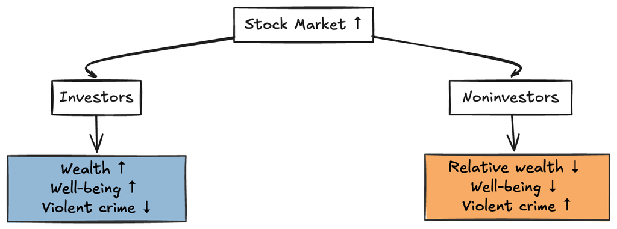

The contrasting predictions are what make this interesting — it’s not just “does X cause Y” but “does X cause Y differently for subgroups?”

**Link to L3**: This is identification thinking. What’s the DGP? What variation are we exploiting? What’s the hypothesis?

## The Paper

### Relative wealth (Mechanism)

#### Investors

- Stock market rises ⤏ **absolute** wealth increases
- Also better off **relative** to average person
- Psychological well-being improves
- Violent crime decreases

#### Noninvestors

- Stock market rises ⤏ **no change** in own wealth
- But now **relatively worse off** compared to investors
- Psychological well-being declines
- Violent crime increases

This is consistent with relative status models (Abel 1990; Gali 1994) and the “keeping up with the Joneses” literature.

## The Paper

### Data: The pipeline you already know

#### Three data sources

1. **Crime**: FBI NIBRS: 55M+ incidents, 2,700 agencies, 1991–2015
2. **Income**: ACS Census: median income by city/county (proxy for investor status)
3. **Returns**: Kenneth French’s website

#### Cleaning decisions

- Filter inconsistent reporters
- Remove agencies with <50 report days,small/remote agencies (<2,000 pop)
- Crime day starts at 6 AM (before market opens)

#### Variable construction

- Crime rates: incidents per 100M population
- Income terciles: high/medium/low as investor proxy
- Standardized returns: $r_t / \sigma_{t,252}$
- Violent crime: assaults + homicides only

**Link to L1–L2**

This **is** the data pipeline from Lectures 1–2. Three raw sources ⤏ clean ⤏ merge ⤏ construct variables. Huck devotes a substantial part of the paper to describing these choices. Remember when 60–70% of your assignment time was data prep?

## The Paper

### Data: Income as investor proxy

#### Why income terciles?

- Malloy et al. (2009) show probability of holding stocks increases significantly with income
- Top tercile ≈ likely investors
- Bottom tercile ≈ likely noninvestors
- Available for all agencies

#### Why violent crime specifically?

- Aggregate crime ⤏ measurement problem: theft in rich areas likely committed by low-income individuals
- Violent crime (assaults, homicides): typically occurs at home, offender known to victim
- 54% of assault victims in middle/high-income households
- 44% assaulted at or near their home
- Minimizes the misattribution problem between offender income and location income

**Link to L2**: This is the “think about your measurement” lesson. Your proxy needs to match your theory.

## The Paper

### Descriptive evidence

Huck (2024), Table 2 — Summary statistics (crime rates per 100M, daily 1991–2015)

|  | Average | Median | SD |
| --- | --- | --- | --- |
| Crime rate (all) | 22,659 | 17,675 | 18,565 |
| High-income | 18,347 | 14,547 | 14,577 |
| Medium-income | 24,215 | 19,618 | 18,894 |
| Low-income | 27,043 | 21,527 | 21,784 |
| Violent crime rate | 4,676 | 2,437 | 7,140 |
| High-income | 3,370 | 1,524 | 5,455 |
| Medium-income | 5,077 | 3,021 | 7,199 |
| Low-income | 6,093 | 3,637 | 8,748 |
| Market return (std.) | 0.038 | 0.082 | 1.044 |

**Link to L2**: Descriptive statistics *before* regressions. Crime increases monotonically from high to low income. Violent crime is ~20% of all crime.

## The Paper

### Panel FE regression

#### The model

$$y_{i,t} = \beta \cdot r_t + \gamma \cdot X_{i,t} + \theta_{i,a(t)} + \mu_{i,m(t)} + \omega_{i,w(t)} + \delta_{i,d(t)} + T_t + \varepsilon_{i,t}$$

|  | What it is | What it absorbs |
| --- | --- | --- |
| $y_{i,t}$ | Crime rate for agency $i$ on day $t$ | Outcome variable |
| $r_t$ | Standardized daily market return | **Coefficient of interest** |
| $X_{i,t}$ | Weather, pollution, sports outcomes, celestial | Daily confounders |
| $\theta_{i,a(t)}$ | Agency × year FE | Local business cycles, demographics |
| $\mu_{i,m(t)}$ | Agency × month-of-year FE | Local seasonal crime patterns |
| $\omega_{i,w(t)}$ | Agency × week-of-month FE | Payday effects |
| $\delta_{i,d(t)}$ | Agency × day-of-week FE | Weekend effects |
| $T_t$ | Turn-of-month + holiday FE | Calendar anomalies |

Standard errors clustered by time and agency.

## The Paper

### Why so many fixed effects?

#### The identification challenge

The concern: maybe something else that happens on the same day drives *both* stock returns *and* crime (e.g., weather, sports, holidays).

#### Huck’s defense

- Agency × year: absorbs local economic conditions that change annually
- Agency × month: absorbs seasonal crime patterns (summer peak, winter trough)
- Agency × day-of-week: absorbs weekend/weekday differences
- Explicit controls for weather, NFL/MLB, moon phases, daylight savings

#### The key insight

Identification occurs within each agency-year. After removing all these patterns, the remaining variation in crime is compared with daily market return fluctuations.

**Link to L4**

This is the **fixed effects logic** taken seriously. Each layer of FE removes another source of confounding. The residual variation is what identifies the effect.

## The Paper

### Differential effects by income (Core test)

The model is estimated separately for high-income (investor) and low-income (noninvestor) locations:

#### Results (violent crime)

Adapted from Huck (2024), Table 3

|  | High-income | Low-income |
| --- | --- | --- |
| Market return | **−12.47***** | **+15.22**** |
|  | (−3.291) | (2.043) |
| % of avg | −0.37% | +0.25% |
| t(HIGH=LOW) |  | 3.313 |

#### Interpretation

- 1 SD market return ↑ ⤏
  - **37 bps decrease** in violent crime for investors
  - **25 bps increase** in violent crime for noninvestors
- Effects are statistically different from each other (t = 3.31)
- **Signs are opposite** — consistent with relative wealth theory

**Link to L3**: Reading regression tables, interpreting coefficients, economic vs statistical significance. This is DiLLMa at publication level.

## The Paper

### Economic magnitude

#### How big is this?

- A 1% increase in the stock market (≈ 1 SD) corresponds to:
  - An additional **76–179 crimes per day** across the US
  - **$7.1–16.8 million in daily costs** to society
  - **$1.8–4.2 billion annualized**
- For investors, the 37 bps decrease in violent crime is comparable to Engelberg and Parsons (2016) finding of a 21 bps decrease in mental health admissions in California after market increases

**Key takeaway**

The stock market has real externalities beyond the portfolios it directly affects. This is what makes it a finance paper with social implications.

## The Paper

### Is this really same-day? (Timing and identification)

#### Leads and lags (Table 4)

|  | t−3 | t−2 | t−1 | **t** | t+1 | t+2 | t+3 |
| --- | --- | --- | --- | --- | --- | --- | --- |
| High | 1.2 | 6.1 | −6.4 | **−12.5***** | −3.0 | −0.1 | 3.8 |
| Low | 6.4 | −9.1 | −3.8 | **15.2**** | 5.0 | 4.7 | 2.1 |

Only the contemporaneous (day $t$) coefficients are significant!

#### What this tells us

- No pre-trends: market returns on t−1, t−2, t−3 don’t predict crime
- No delayed effects: market returns don’t affect crime in coming days
- Within the day: effect is strongest **after markets close**
- This is consistent with: see news ⤏ emotional response ⤏ same-day behavior

**Link to L5**: This is event study logic applied to crime. The leads/lags table is structurally identical to a CAR event window. The “no pre-trend” finding mirrors the parallel trends test from L4.

## The Paper

### Defending the identification (Robustness)

Good empirical work doesn’t just show one result, it shows the result survives scrutiny.

#### What Huck tests

- **Alternative investor proxies**: IRS dividend data, SCF probit model — same results
- **Alcohol channel**: ruled out (crime-return relationship not driven by drinking)
- **At-home violence**: strongest for male-on-female domestic violence — location matches offender
- **Earnings surprises**: local firm announcements with **daily FE** — absorbs *all* common daily shocks

#### Why this matters

Each robustness check addresses a specific threat to identification:

- Alternative proxies ⤏ measurement concern
- Alcohol ⤏ omitted variable / alternative mechanism
- At-home violence ⤏ misattribution concern
- Earnings surprises ⤏ common shock concern

**Link to L4–L5**: Robustness checks are how you defend your identification strategy. Each addresses a specific concern. This is exactly what you do in A5 (Dieselgate) and will do in A6.

## The Paper

### Earnings surprises

#### Why this test is particularly convincing

- Uses local firm earnings surprises (not market-wide returns)
- Includes daily fixed effects that absorb **any** common daily shock
- Earnings announcements are salient reports on **past** performance ⤏ should be unrelated to other daily news
- Exploits the local bias of investors: people pay more attention to firms headquartered nearby

#### Result

Positive local earnings surprises are associated with:

- **Decreased** violent crime in high-income (investor) areas
- **Increased** violent crime in low-income (noninvestor) areas

Same contrasting pattern — even after removing all common daily variation.

## The Paper

### What makes this paper work?

| Paper element | Skill/Tool | You learned this in |
| --- | --- | --- |
| Three data sources ⤏ merged panel | Data wrangling, merge, reshape | **L1** |
| Summary statistics, time series plots | EDA, distributional analysis | **L2** |
| OLS regression, interpreting coefficients | OLS, hypothesis testing | **L3** |
| Agency × year FE, agency × seasonal FE | Panel fixed effects, TWFE | **L4** |
| Leads/lags analysis (event window logic) | Event study timing | **L5** |
| Interaction terms (return × income group) | Differential effects, DiD intuition | **L4** |
| Clustered standard errors | Correct inference | **L3–L5** |
| Robustness to alternative specifications | Defending identification | **L3–L5** |

**The point**

You have the entire toolkit to read, understand, and replicate this paper. That’s what you’ll do in Assignment 6.

# Part 3: Your Turn — The Dutch Replication

## Assignment 6

### What stays, what changes?

#### What stays the same

- The research question and hypothesis
- The empirical specification structure
- Income terciles as investor proxy
- Interaction terms for differential effects
- Fixed effects and robustness checks

#### What changes

- **Country**: Netherlands instead of US
- **Market**: AEX index instead of S&P 500
- **Crime data**: CBS municipality data instead of FBI NIBRS
- **Frequency**: Monthly instead of daily
- **Geography**: Municipalities instead of cities
- **Income**: CBS municipality median income instead of ACS

**Important difference**

Monthly frequency is the biggest limitation. We **cannot** test Huck’s timing analysis (Table 4–5) or identify same-day effects. This is a key limitation you’ll discuss in Section 14.

## Assignment 6

### Part A: The data pipeline

#### Three raw datasets

1. **crime_data.dta**: Municipality × month panel of crime incidents by type
2. **income_data.dta**: Cross-sectional average median income per municipality (2011–2018)
3. **aex_daily.dta**: Daily AEX index closing prices

#### Your pipeline

- Section 2: Load and examine
- Section 3: Calculate standardized returns (trailing 252-day SD, then aggregate to monthly)
- Section 4: Reshape crime data (long ⤏ wide)
- Section 5: Merge all three datasets
- Section 6: Create analysis variables (terciles, interactions)

> Remember: **Part A is 60–70% of the work**. That’s normal.

## Assignment 6

### Part B: The analysis

#### Section 7–8: Descriptive statistics & visualization

Before regressions, you create:

- Summary statistics by income tercile
- Time series of crime rates (trending down? seasonal patterns?)
- Crime rates overlaid with AEX returns
- Crime trends split by income group

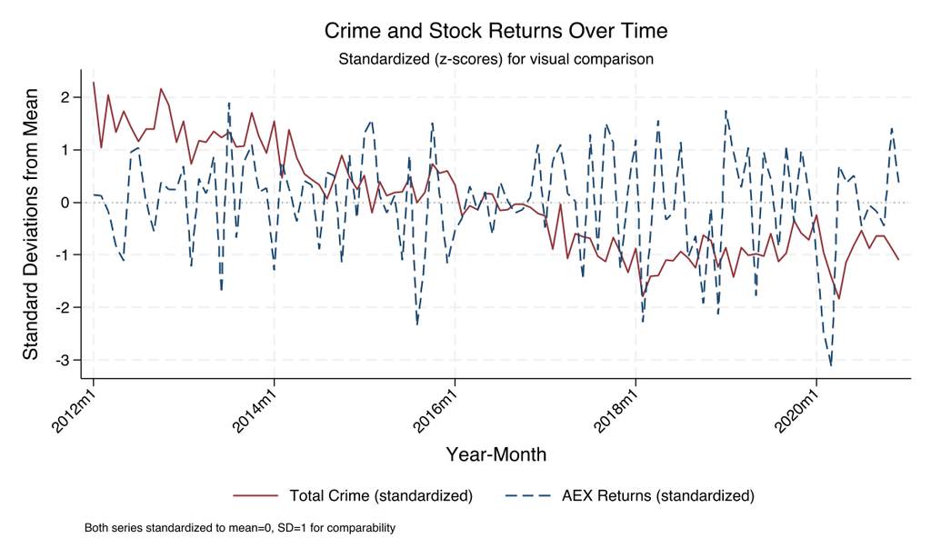

**Link to L2**

This is the “look before you regress” principle. Your descriptive statistics should reveal patterns that your regressions will formalize.

## Assignment 6

### Baseline panel regression (Section 9)

The baseline model estimates the average effect of AEX returns on crime across **all** municipalities:

$$\text{Crime}_{it} = \beta \cdot r_t^{AEX} + \alpha_i + \varepsilon_{i,t}$$

- Municipality fixed effects ($\alpha_i$) absorb time-invariant differences
- This tests: “Do stock returns predict crime on average?”
- But it does **not** test Huck’s key hypothesis about differential effects

This is the “warm-up” regression — like running a naive OLS before adding controls in L3.

## Assignment 6

### The core test (Section 10)

#### Our specification (with interactions)

$$\text{Crime}_{it} = \beta_0 + \beta_1 \text{Returns}_t + \beta_2 (\text{Returns}_t \times \text{High}_{i}) + \beta_3 (\text{Returns}_t \times \text{Low}_{i}) + \alpha_i + \varepsilon_{it}$$

Where:

- $\beta_1$ = Effect in medium-income areas (reference group)
- $\beta_1 + \beta_2$ = Effect in high-income areas
- $\beta_1 + \beta_3$ = Effect in low-income areas

**Key test:** Is $\beta_2 < 0$ (high-income negative) and $\beta_3 > 0$ (low-income positive)?

## Assignment 6

### Two-way fixed effects & robustness (Section 11 & 12)

#### Two-way fixed effects (TWFE)

$$\text{Crime}_{it} = \beta_2 (\text{Returns}_t \times \text{High}_{i}) + \beta_3 (\text{Returns}_t \times \text{Low}_{i}) + \alpha_i + \gamma_t + \varepsilon_{it}$$

Where:

- $\alpha_i$ = Municipality fixed effects
- $\gamma_t$ = Time (year-month) fixed effects
- **Note:** The main return effect $\beta_1 \text{Returns}_t$ is **absorbed** by time FE because all municipalities have the same return in month $t$

## Assignment 6

### Two-way fixed effects & robustness (Section 11 & 12)

#### Section 12: Robustness checks

- **Log crime**: addresses skewed distribution
- **Assault only**: closer to Huck’s violent crime measure
- **High-volatility months**: does the effect strengthen when market moves are larger?

## Assignment 6

### The publication-quality table (Section 13)

Section 13 asks you to create a single table combining all specifications:

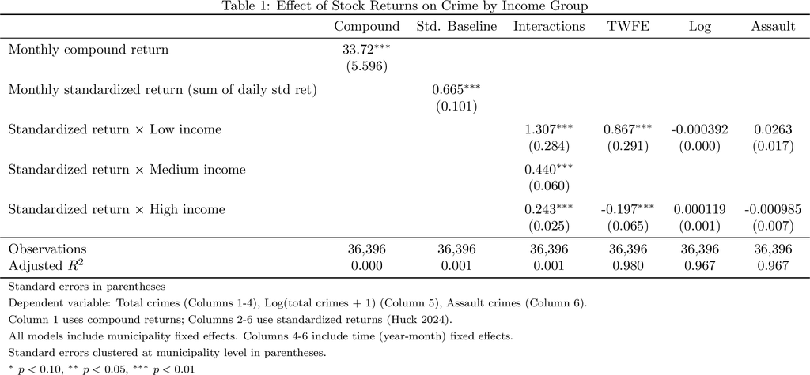

**Link to L3**: This is the same skill as the DiLLMa regression table — building up from naive to fully specified, each column addressing a new concern.

# Part 3B: Interpretation, Limitations & Thesis

## Section 14: Interpreting Your Findings

### What a good summary looks like

#### Structure to follow

1. **Main result**: Do you find differential effects?
2. **Signs**: Consistent with Huck’s theory?
3. **Statistical significance**: Are key coefficients significant?
4. **Economic magnitude**: How large are effects?
5. **Robustness**: Do results hold across specifications?
6. **Comparison to Huck**: Same or different from US results?

#### Common mistakes to avoid

🤦‍♀️ Just listing coefficients without interpretation

🤦‍♀️ Over-claiming causality (“AEX returns *cause* crime”)

🤦‍♀️ Ignoring null results (“we didn’t find it, so we won’t discuss it”)

💰 Null results are informative! If you don’t find the same pattern, that’s a finding worth discussing.

## Section 14: Interpreting Your Findings

### What if you don’t replicate Huck’s results?

Think about why:

#### Data-related reasons

- Monthly ≠ daily: effects may wash out at lower frequency
- AEX is a smaller market with fewer household investors
- CBS crime data has different reporting standards than FBI NIBRS

#### Context-related reasons

- Dutch stock participation rate may differ from US
- Welfare state ⤏ less relative deprivation?
- Cultural differences in violence as stress response
- Netherlands is geographically smaller ⤏ less local variation

**For your thesis**

A well-explained null finding shows deeper understanding than a weak positive with no discussion.

## Section 14: Limitations

### How to write honest limitations

#### The formula: What ⤏ Why it matters ⤏ How it differs from Huck

#### Good limitations

“Monthly data cannot test within-day timing effects (Huck’s Table 4–5), limiting our ability to distinguish same-day from lagged effects.”

“Municipality-level income is an imperfect proxy for investor participation; Huck uses census micro-data allowing for more precise classification.”

“A single market return means no cross-sectional variation in ‘treatment’ within a given month — all municipalities face the same AEX return.”

#### Bad limitations

“We don’t have enough data” ⤏ Too vague. What data? Why does it matter?

“Results might be wrong” ⤏ Undermines everything without explaining what could be wrong.

“The Netherlands is different from the US” ⤏ *How* is it different, and why does that affect your specific test?

## Section 14: Limitations

### The key limitations for Assignment 6

[output not shown]

## Section 14: What Would Strengthen the Analysis?

### Think creatively

#### Better data

- Daily crime data (if available from CBS)
- Individual brokerage account data by municipality (AFM, DEGIRO, or similar)
- Survey data on stock market awareness by region

#### Natural experiments

- Neo-broker entry: Trade Republic, BUX, DEGIRO expansion ⤏ DiD design
- Tax policy changes affecting participation (e.g., box 3 reforms)
- COVID market crash (extreme, salient event)

#### Alternative outcomes

- Health data (hospital admissions, mental health)
- Google Trends for financial distress keywords
- Consumer confidence by region

#### Extensions

- Cross-country comparison (UK has better crime data)
- Crypto markets (more volatile, younger investors, higher awareness)
- Social media sentiment as mediator

## Sections 15 to 16: The Thesis Connection

### You just completed a mini-thesis

#### Your MSc thesis modules

1. **Module 1**: Literature review & research question
2. **Module 2**: Replication of published results with new/similar data
3. **Module 3**: Extension or new analysis building on Module 2

#### What you did in A6

- Read a published paper ⤏ **Module 1**
- Replicated the methodology with Dutch data ⤏ **Module 2**
- Discussed extensions and improvements ⤏ **Module 3 ideas**

**The direct connection**

Assignment 6 **is** Module 2. Your improvement suggestions in Section 14.3 **are** Module 3 ideas. The skills you practiced — data wrangling, panel regression, robustness, interpretation — are exactly what your thesis demands.

# Part 4: Wrap-Up

## The Role of AI in Your Thesis Workflow

### You need to understand the method to guide the tool

#### What AI is good at

- Writing Stata/R/Python code from clear instructions
- Debugging syntax errors
- Formatting tables and figures
- Summarizing literature

#### What AI cannot do for you

- Choose your identification strategy
- Decide which fixed effects to include and **why**
- Interpret a null result
- Write an honest limitations discussion
- Defend your choices in a thesis defense

> “If you can’t explain *why* you’re including municipality fixed effects, the LLM can’t save you in your thesis defense.”

**The value chain**

**Understanding ⤏ Design ⤏ Implementation**. AI helps most with the last step, least with the first. This course focused on the first two — because those are what make you a researcher, not a code typist.

## What You Can Now Do

### The skills you built

#### Technical skills

- Build a data pipeline from raw sources to analysis-ready panels
- Run and interpret OLS, panel FE, DiD, event studies, and Fama–MacBeth regressions
- Create publication-quality tables and figures
- Conduct and explain robustness checks

#### Research skills

- Read and critically evaluate an empirical finance paper
- Choose methods appropriate to your research question and data
- Identify threats to identification and address them
- Write honest interpretation and limitation discussions
- Replicate published work and evaluate generalizability

## Practical Thesis Advice

### Three things to remember

#### 1. Start with the data, not the regression

If you can’t describe your data structure, you’re not ready to estimate anything. Invest time in Part A.

#### 2. Replicate before you extend

Get the baseline working before you try new specifications. Confirm that your data pipeline produces sensible numbers.

#### 3. Limitations aren’t weakness — they’re depth

Every published paper has limitations. Acknowledging them shows you understand the research design. Not acknowledging them suggests you don’t.

## Final Assignment Reminders

### A6 practical details

- **Deadline**: March 25, 2026
- **Structure**: Part A (data prep) ⤏ Part B (analysis) ⤏ Part C (interpretation)
- **Grading**: (Auto-)graded through Section 13; **Sections 14–16 are ungraded** - “Food for thought”

Thank You!

It’s been a pleasure. Good luck with Assignment 6 and your thesis!

## References

Abel, Andrew B. 1990. “Asset Prices Under Habit Formation and Catching up with the Joneses.” *The American Economic Review* 80 (2): 38–42. http://www.jstor.org/stable/2006539.

Card, David, and Gordon B Dahl. 2011. “Family Violence and Football: The Effect of Unexpected Emotional Cues on Violent Behavior.” *The Quarterly Journal of Economics* 126 (1): 103–43.

Engelberg, Joseph, and Christopher A Parsons. 2016. “Worrying about the Stock Market: Evidence from Hospital Admissions.” *The Journal of Finance* 71 (3): 1227–50.

Gali, Jordi. 1994. “Keeping up with the Joneses: Consumption Externalities, Portfolio Choice, and Asset Prices.” *Journal of Money, Credit and Banking* 26 (1): 1–8.

Huck, John R. 2024. “The Psychological Externalities of Investing: Evidence from Stock Returns and Crime.” *The Review of Financial Studies* 37 (7): 2273–314.

Malloy, Christopher J, Tobias J Moskowitz, and Annette Vissing-Jørgensen. 2009. “Long-Run Stockholder Consumption Risk and Asset Returns.” *The Journal of Finance* 64 (6): 2427–79.